# Introduction

### Overview

For our EDA project, I analyzde data coming from the UN data website. It is titled "Intentional homicide victims by sex, counts and rates per 100,000 population". I found this data using Tracy Coyne's research guide, and it comes from data.un.org. It's information spans across over 60 million reports, and is associated with the United Nations Statistics Division. This data shows the counts and rates of intentional homicide in many countries around the world from the years 2000 to 2020.

### Importance

Although this is a bit of a morbid subject, I have always been incredibly interested in the world of true crime. I thought it would be interesting to see the statistical differences in homicides between sexes not just in one country but between many countries. I think it would also be interesting to see if countries which are lacking in women's rights have a different ratio of murders between men and women.

### Hypotheses

Firstly, I hypothesize that intentional homicide rates in females will be higher in countries with poor women's rights. Secondly, I believe that overall intentional homicide rates in males will be greater than that in females in most all of the countries in question. This is simply due to a higher percentage of violent crime being committed by males in general.

# Data Explained

### Cleaning the Data

link: http://data.un.org/DocumentData.aspx?id=444

This data needed quite a bit of cleaning before being able to use it for my analysis.

1. Firstly to make things more simple, I cut out the "Source" column and all empty cells.
2. After dropping empty cells, I had to isolate countries which had data for both genders and every year 2000-2020.
3. I also decided to only focus on the rate of intentional homicide, not the number, as rate is more of a fair comparison between countries with different population sizes. To do this I had to drop all of the "Number" columns
4. I then had to rename the unnamed columns to correspond with the years 2000-2020.
5. Next, I had to use the melt function in order to change my "Year" rows into one "Year" column.

```python
import pandas as pd

df = pd.read_excel(r'eda_data.xls')
print(df)
```

```
             Region                                          Subregion  \
0               NaN                                                NaN
1            Africa                                    Northern Africa
2            Africa                                    Northern Africa
3            Africa                                    Northern Africa
4            Africa                                    Northern Africa
..              ...                                                ...
341  UNODC Estimate  Data based on a statistical modification of an...
342  UNSDC Adjusted  Data based on an a statistical modification of...
343     NP Adjusted  Data based on an a statistical modification of...
344    SDG Adjusted  Data based on an a statistical modification of...
345    CTS Adjusted  Data based on an a statistical modification of...

     Country  Gender        Source  \
0        NaN     NaN           NaN
```

[output cut: 64 more lines]

```python
#drop source column and empty cells
df = df.drop('Source', axis=1)
df = df.dropna(inplace = False)
```

```python
print(df)
```

```
       Region                        Subregion             Country  Gender  \
45   Americas  Latin America and the Caribbean              Brazil  Female
46   Americas  Latin America and the Caribbean              Brazil    Male
51   Americas  Latin America and the Caribbean            Colombia  Female
52   Americas  Latin America and the Caribbean            Colombia    Male
61   Americas  Latin America and the Caribbean             Ecuador  Female
62   Americas  Latin America and the Caribbean             Ecuador    Male
79   Americas  Latin America and the Caribbean              Mexico  Female
80   Americas  Latin America and the Caribbean              Mexico    Male
83   Americas  Latin America and the Caribbean              Panama  Female
84   Americas  Latin America and the Caribbean              Panama    Male
89   Americas  Latin America and the Caribbean         Puerto Rico  Female
145      Asia                    Southern Asia               India  Female
146      Asia                    Southern Asia               India    Male
153      Asia                     Western Asia             Armenia  Female
```

[output cut: 251 more lines]

```python
df.drop(columns=df.columns[4:25], inplace=True)
```

```python
df.rename(columns={'Rates of intentional homicide by sex':'2000'}, inplace=True)
df.rename(columns={'Unnamed: 27':'2001'}, inplace=True)
df.rename(columns={'Unnamed: 28':'2002'}, inplace=True)
df.rename(columns={'Unnamed: 29':'2003'}, inplace=True)
df.rename(columns={'Unnamed: 30':'2004'}, inplace=True)
df.rename(columns={'Unnamed: 31':'2005'}, inplace=True)
df.rename(columns={'Unnamed: 32':'2006'}, inplace=True)
df.rename(columns={'Unnamed: 33':'2007'}, inplace=True)
df.rename(columns={'Unnamed: 34':'2008'}, inplace=True)
df.rename(columns={'Unnamed: 35':'2009'}, inplace=True)
df.rename(columns={'Unnamed: 36':'2010'}, inplace=True)
df.rename(columns={'Unnamed: 37':'2011'}, inplace=True)
df.rename(columns={'Unnamed: 38':'2012'}, inplace=True)
df.rename(columns={'Unnamed: 39':'2013'}, inplace=True)
df.rename(columns={'Unnamed: 40':'2014'}, inplace=True)
df.rename(columns={'Unnamed: 41':'2015'}, inplace=True)
df.rename(columns={'Unnamed: 42':'2016'}, inplace=True)
df.rename(columns={'Unnamed: 43':'2017'}, inplace=True)
df.rename(columns={'Unnamed: 44':'2018'}, inplace=True)
df.rename(columns={'Unnamed: 45':'2019'}, inplace=True)
df.rename(columns={'Unnamed: 46':'2020'}, inplace=True)
print(df)
```

```
       Region                        Subregion             Country  Gender  \
45   Americas  Latin America and the Caribbean              Brazil  Female
46   Americas  Latin America and the Caribbean              Brazil    Male
51   Americas  Latin America and the Caribbean            Colombia  Female
52   Americas  Latin America and the Caribbean            Colombia    Male
61   Americas  Latin America and the Caribbean             Ecuador  Female
62   Americas  Latin America and the Caribbean             Ecuador    Male
79   Americas  Latin America and the Caribbean              Mexico  Female
80   Americas  Latin America and the Caribbean              Mexico    Male
83   Americas  Latin America and the Caribbean              Panama  Female
84   Americas  Latin America and the Caribbean              Panama    Male
89   Americas  Latin America and the Caribbean         Puerto Rico  Female
145      Asia                    Southern Asia               India  Female
146      Asia                    Southern Asia               India    Male
153      Asia                     Western Asia             Armenia  Female
```

[output cut: 145 more lines]

```python
col = ['2000','2001','2002','2003','2004','2005','2006','2007','2008','2009','2010','2011','2012','2013',
       '2014','2015','2016','2017','2018','2019','2020']
df_long = (pd.melt(df, id_vars = ['Region','Subregion','Country','Gender'], value_vars = col, var_name = 'Year',
                   value_name = 'Rate'))
df_long.info()
```

```
<class 'pandas.core.frame.DataFrame'>
RangeIndex: 1071 entries, 0 to 1070
Data columns (total 6 columns):
 #   Column     Non-Null Count  Dtype
---  ------     --------------  -----
 0   Region     1071 non-null   object
 1   Subregion  1071 non-null   object
 2   Country    1071 non-null   object
 3   Gender     1071 non-null   object
 4   Year       1071 non-null   object
 5   Rate       1071 non-null   float64
dtypes: float64(1), object(5)
memory usage: 50.3+ KB
```

```python
print(df_long)
```

```
        Region                        Subregion      Country  Gender  Year  \
0     Americas  Latin America and the Caribbean       Brazil  Female  2000
1     Americas  Latin America and the Caribbean       Brazil    Male  2000
2     Americas  Latin America and the Caribbean     Colombia  Female  2000
3     Americas  Latin America and the Caribbean     Colombia    Male  2000
4     Americas  Latin America and the Caribbean      Ecuador  Female  2000
...        ...                              ...          ...     ...   ...
1066    Europe                   Western Europe  Netherlands    Male  2020
1067    Europe                   Western Europe  Switzerland  Female  2020
1068    Europe                   Western Europe  Switzerland    Male  2020
1069   Oceania        Australia and New Zealand    Australia  Female  2020
1070   Oceania        Australia and New Zealand    Australia    Male  2020

        Rate
0       4.24
1      48.03
2       9.52
3     126.70
4       2.29
...      ...
1066    1.46
1067    0.62
1068    0.47
1069    0.58
1070    1.18

[1071 rows x 6 columns]
```

```python
df_long['Region'].value_counts()
```

```
Europe      714
Americas    231
Asia         84
Oceania      42
Name: Region, dtype: int64
```

```python
df_long['Subregion'].value_counts()
```

```
Eastern Europe                     252
Latin America and the Caribbean    231
Northern Europe                    210
Western Europe                     147
Southern Europe                    105
Southern Asia                       42
Western Asia                        42
Australia and New Zealand           42
Name: Subregion, dtype: int64
```

```python
df_long['Country'].value_counts()
```

```
Brazil                42
Colombia              42
Switzerland           42
Netherlands           42
Austria               42
Serbia                42
Croatia               42
Albania               42
Sweden                42
Norway                42
Estonia               42
Denmark               42
Slovakia              42
Russian Federation    42
Romania               42
Poland                42
Hungary               42
Bulgaria              42
Armenia               42
India                 42
Panama                42
Mexico                42
Ecuador               42
Australia             42
Lithuania             21
Puerto Rico           21
Germany               21
Name: Country, dtype: int64
```

We have to drop Lithuania, Puerto Rico and Germany because they do not have the same values as the rest.

```python
df_filtered = df_long[df_long['Country'] != 'Lithuania']
df_filtered1 = df_filtered[df_filtered['Country'] != 'Puerto Rico']
df_filtered2 = df_filtered1[df_filtered1['Country'] != 'Germany']

print(df_filtered2)
```

```
        Region                        Subregion      Country  Gender  Year  \
0     Americas  Latin America and the Caribbean       Brazil  Female  2000
1     Americas  Latin America and the Caribbean       Brazil    Male  2000
2     Americas  Latin America and the Caribbean     Colombia  Female  2000
3     Americas  Latin America and the Caribbean     Colombia    Male  2000
4     Americas  Latin America and the Caribbean      Ecuador  Female  2000
...        ...                              ...          ...     ...   ...
1066    Europe                   Western Europe  Netherlands    Male  2020
1067    Europe                   Western Europe  Switzerland  Female  2020
1068    Europe                   Western Europe  Switzerland    Male  2020
1069   Oceania        Australia and New Zealand    Australia  Female  2020
1070   Oceania        Australia and New Zealand    Australia    Male  2020

        Rate
0       4.24
1      48.03
2       9.52
3     126.70
4       2.29
...      ...
1066    1.46
1067    0.62
1068    0.47
1069    0.58
1070    1.18

[1008 rows x 6 columns]
```

```python
print(df_filtered2['Rate'].describe())
```

```
count    1008.000000
mean        6.692738
std        14.409103
min         0.340000
25%         0.980000
50%         1.795000
75%         4.192500
max       130.510000
Name: Rate, dtype: float64
```

```python
df_filtered2.to_excel('eda_phase2final.xlsx')
```

# Results

Below is my final data:

```python
data = df_filtered2
print(data)
```

```
        Region                        Subregion      Country  Gender  Year  \
0     Americas  Latin America and the Caribbean       Brazil  Female  2000
1     Americas  Latin America and the Caribbean       Brazil    Male  2000
2     Americas  Latin America and the Caribbean     Colombia  Female  2000
3     Americas  Latin America and the Caribbean     Colombia    Male  2000
4     Americas  Latin America and the Caribbean      Ecuador  Female  2000
...        ...                              ...          ...     ...   ...
1066    Europe                   Western Europe  Netherlands    Male  2020
1067    Europe                   Western Europe  Switzerland  Female  2020
1068    Europe                   Western Europe  Switzerland    Male  2020
1069   Oceania        Australia and New Zealand    Australia  Female  2020
1070   Oceania        Australia and New Zealand    Australia    Male  2020

        Rate
0       4.24
1      48.03
2       9.52
3     126.70
4       2.29
...      ...
1066    1.46
1067    0.62
1068    0.47
1069    0.58
1070    1.18

[1008 rows x 6 columns]
```

Let's first address finding the places with highest rates of intentional homicide. Firstly, let's look at the top 50 rate values in our data. This shows the countries and years which had the highest rates of intentional homicide by sex between the years of 2000 to 2020.

```python
top50 = data.sort_values('Rate', ascending=False).head(50)
top50
```

|  | Region | Subregion | Country | Gender | Year | Rate |
| --- | --- | --- | --- | --- | --- | --- |
| 105 | Americas | Latin America and the Caribbean | Colombia | Male | 2002 | 130.51 |
| 54 | Americas | Latin America and the Caribbean | Colombia | Male | 2001 | 129.88 |
| 3 | Americas | Latin America and the Caribbean | Colombia | Male | 2000 | 126.70 |
| 156 | Americas | Latin America and the Caribbean | Colombia | Male | 2003 | 105.86 |
| 207 | Americas | Latin America and the Caribbean | Colombia | Male | 2004 | 90.11 |
| 258 | Americas | Latin America and the Caribbean | Colombia | Male | 2005 | 79.51 |
| 309 | Americas | Latin America and the Caribbean | Colombia | Male | 2006 | 76.31 |
| 360 | Americas | Latin America and the Caribbean | Colombia | Male | 2007 | 73.77 |
| 411 | Americas | Latin America and the Caribbean | Colombia | Male | 2008 | 68.60 |
| 615 | Americas | Latin America and the Caribbean | Colombia | Male | 2012 | 66.68 |
| 462 | Americas | Latin America and the Caribbean | Colombia | Male | 2009 | 66.38 |
| 564 | Americas | Latin America and the Caribbean | Colombia | Male | 2011 | 66.05 |
| 513 | Americas | Latin America and the Caribbean | Colombia | Male | 2010 | 64.23 |
| 666 | Americas | Latin America and the Caribbean | Colombia | Male | 2013 | 62.31 |
| 868 | Americas | Latin America and the Caribbean | Brazil | Male | 2017 | 57.43 |
| 817 | Americas | Latin America and the Caribbean | Brazil | Male | 2016 | 55.60 |
| 715 | Americas | Latin America and the Caribbean | Brazil | Male | 2014 | 54.82 |
| 925 | Americas | Latin America and the Caribbean | Mexico | Male | 2018 | 53.09 |
| 766 | Americas | Latin America and the Caribbean | Brazil | Male | 2015 | 53.08 |
| 717 | Americas | Latin America and the Caribbean | Colombia | Male | 2014 | 52.90 |
| 613 | Americas | Latin America and the Caribbean | Brazil | Male | 2012 | 52.48 |
| 664 | Americas | Latin America and the Caribbean | Brazil | Male | 2013 | 52.44 |
| 154 | Americas | Latin America and the Caribbean | Brazil | Male | 2003 | 52.35 |
| 976 | Americas | Latin America and the Caribbean | Mexico | Male | 2019 | 52.13 |
| 103 | Americas | Latin America and the Caribbean | Brazil | Male | 2002 | 51.51 |
| 1027 | Americas | Latin America and the Caribbean | Mexico | Male | 2020 | 50.97 |
| 768 | Americas | Latin America and the Caribbean | Colombia | Male | 2015 | 50.30 |
| 52 | Americas | Latin America and the Caribbean | Brazil | Male | 2001 | 50.20 |
| 919 | Americas | Latin America and the Caribbean | Brazil | Male | 2018 | 49.78 |
| 126 | Europe | Eastern Europe | Russian Federation | Male | 2002 | 49.46 |
| 511 | Americas | Latin America and the Caribbean | Brazil | Male | 2010 | 49.46 |
| 460 | Americas | Latin America and the Caribbean | Brazil | Male | 2009 | 49.24 |
| 205 | Americas | Latin America and the Caribbean | Brazil | Male | 2004 | 48.93 |
| 562 | Americas | Latin America and the Caribbean | Brazil | Male | 2011 | 48.90 |
| 409 | Americas | Latin America and the Caribbean | Brazil | Male | 2008 | 48.55 |
| 307 | Americas | Latin America and the Caribbean | Brazil | Male | 2006 | 48.47 |
| 819 | Americas | Latin America and the Caribbean | Colombia | Male | 2016 | 48.12 |
| 1 | Americas | Latin America and the Caribbean | Brazil | Male | 2000 | 48.03 |
| 256 | Americas | Latin America and the Caribbean | Brazil | Male | 2005 | 47.46 |
| 921 | Americas | Latin America and the Caribbean | Colombia | Male | 2018 | 47.29 |
| 75 | Europe | Eastern Europe | Russian Federation | Male | 2001 | 47.19 |
| 874 | Americas | Latin America and the Caribbean | Mexico | Male | 2017 | 46.74 |
| 358 | Americas | Latin America and the Caribbean | Brazil | Male | 2007 | 46.74 |
| 177 | Europe | Eastern Europe | Russian Federation | Male | 2003 | 46.65 |
| 870 | Americas | Latin America and the Caribbean | Colombia | Male | 2017 | 46.52 |
| 24 | Europe | Eastern Europe | Russian Federation | Male | 2000 | 44.89 |
| 972 | Americas | Latin America and the Caribbean | Colombia | Male | 2019 | 44.65 |
| 228 | Europe | Eastern Europe | Russian Federation | Male | 2004 | 44.13 |
| 568 | Americas | Latin America and the Caribbean | Mexico | Male | 2011 | 43.27 |
| 1023 | Americas | Latin America and the Caribbean | Colombia | Male | 2020 | 42.45 |

Our top 50 highest rates seem to have some trends in the Region column. Let's analyze our data based on Region. This will break our data down into regions including Europe, Americas, Asia, and Oceania.

```python
europe = data[data['Region'] == 'Europe']
```

```
([0, 1, 2, 3, 4, 5, 6, 7, 8, 9, 10, 11, 12, 13, 14, 15],
 [Text(0, 0, 'Bulgaria'),
```

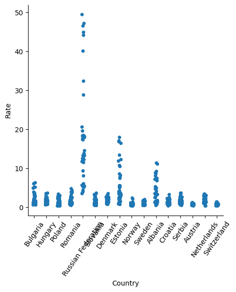

```python
import seaborn as sns
sns.catplot(data=europe, x="Country", y="Rate")
plt.xticks(rotation=55)
```

```
([0, 1, 2, 3, 4],
 [Text(0, 0, 'Brazil'),
```

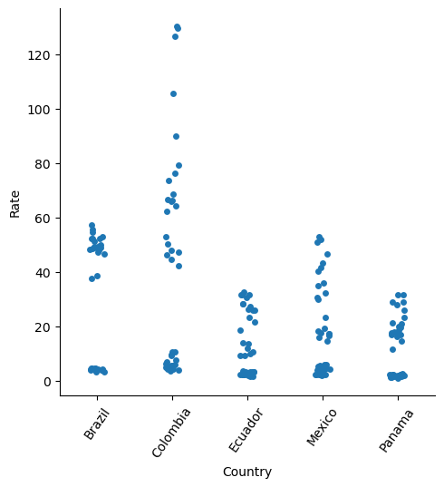

```python
americas = data[data['Region'] == 'Americas']
sns.catplot(data=americas, x="Country", y="Rate")
plt.xticks(rotation=55)
```

```
([0, 1], [Text(0, 0, 'India'), Text(1, 0, 'Armenia')])
```

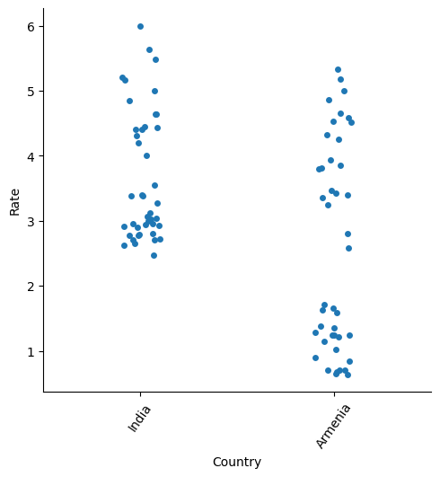

```python
asia = data[data['Region'] == 'Asia']
sns.catplot(data=asia, x="Country", y="Rate")
plt.xticks(rotation=55)
```

```
([0], [Text(0, 0, 'Australia')])
```

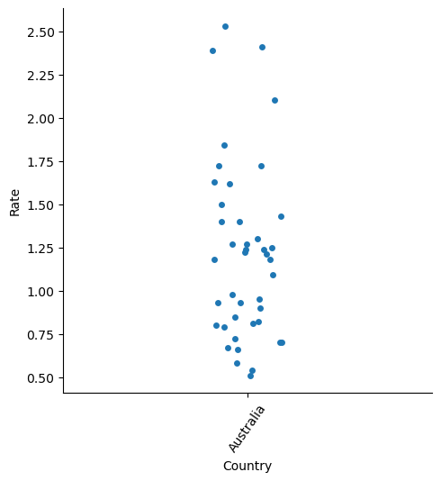

```python
oceania = data[data['Region'] == 'Oceania']
sns.catplot(data=oceania, x="Country", y="Rate")
plt.xticks(rotation=55)
```

Another way which can be helpful in analyzing our data would be to look at the mean rates of intentional homicide in each country. This will give us each country's mean rate of intentional homicide in males and females between the years 2000 and 2020.

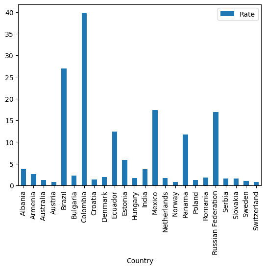

```python
countrymeans = data.groupby('Country').mean(numeric_only = True)
countrymeans
countrymeans.plot(kind = 'bar')
```

When comparing our overall data and the means we calculated above, it is apparent that the intentional homicide rates of males seem to be much higher than intentional homicide rates of females. This is also shown by our 'top 50' highest rates showing only male data. Let's separate the male and female data in order to get a better look at how gender comes into play within our data.

```python
male_only = data[data['Gender'] == 'Male']
male_only
```

|  | Region | Subregion | Country | Gender | Year | Rate |
| --- | --- | --- | --- | --- | --- | --- |
| 1 | Americas | Latin America and the Caribbean | Brazil | Male | 2000 | 48.03 |
| 3 | Americas | Latin America and the Caribbean | Colombia | Male | 2000 | 126.70 |
| 5 | Americas | Latin America and the Caribbean | Ecuador | Male | 2000 | 26.52 |
| 7 | Americas | Latin America and the Caribbean | Mexico | Male | 2000 | 19.46 |
| 9 | Americas | Latin America and the Caribbean | Panama | Male | 2000 | 17.68 |
| ... | ... | ... | ... | ... | ... | ... |
| 1061 | Europe | Southern Europe | Serbia | Male | 2020 | 1.54 |
| 1063 | Europe | Western Europe | Austria | Male | 2020 | 0.63 |
| 1066 | Europe | Western Europe | Netherlands | Male | 2020 | 1.46 |
| 1068 | Europe | Western Europe | Switzerland | Male | 2020 | 0.47 |
| 1070 | Oceania | Australia and New Zealand | Australia | Male | 2020 | 1.18 |

504 rows × 6 columns

```python
female_only = data[data['Gender'] == 'Female']
female_only
```

|  | Region | Subregion | Country | Gender | Year | Rate |
| --- | --- | --- | --- | --- | --- | --- |
| 0 | Americas | Latin America and the Caribbean | Brazil | Female | 2000 | 4.24 |
| 2 | Americas | Latin America and the Caribbean | Colombia | Female | 2000 | 9.52 |
| 4 | Americas | Latin America and the Caribbean | Ecuador | Female | 2000 | 2.29 |
| 6 | Americas | Latin America and the Caribbean | Mexico | Female | 2000 | 2.55 |
| 8 | Americas | Latin America and the Caribbean | Panama | Female | 2000 | 1.93 |
| ... | ... | ... | ... | ... | ... | ... |
| 1060 | Europe | Southern Europe | Serbia | Female | 2020 | 0.52 |
| 1062 | Europe | Western Europe | Austria | Female | 2020 | 0.81 |
| 1065 | Europe | Western Europe | Netherlands | Female | 2020 | 1.01 |
| 1067 | Europe | Western Europe | Switzerland | Female | 2020 | 0.62 |
| 1069 | Oceania | Australia and New Zealand | Australia | Female | 2020 | 0.58 |

504 rows × 6 columns

Now that we have separate datasets showing male data and female data, let's compare the mean rates of each country between the genders.

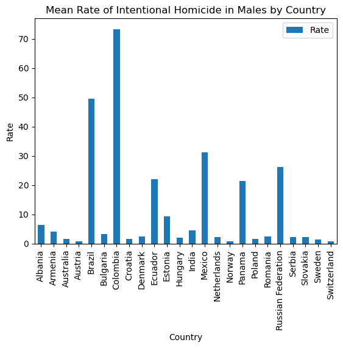

```python
countrymeansmale = male_only.groupby('Country').mean(numeric_only = True)
countrymeansmale
countrymeansmale.plot(kind='bar', title='Mean Rate of Intentional Homicide in Males by Country',
               ylabel='Rate', xlabel='Country')
```

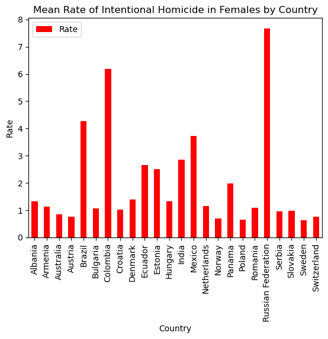

```python
countrymeansfemale = female_only.groupby('Country').mean(numeric_only = True)
countrymeansfemale
countrymeansfemale.plot(kind='bar', title='Mean Rate of Intentional Homicide in Females by Country',
               ylabel='Rate', xlabel='Country', color='red')
```

We can notice very dramatic difference in the scale of the "Rate" axis between our male and female data. Let's make a graphic where we can see male and female data together to show this dramatic difference between the genders. To do this, we must look at a specific year within our dataset, so let's look at the year 2000.

```python
male_only2000 = male_only[male_only['Year'] == '2000']
male_only2000
```

|  | Region | Subregion | Country | Gender | Year | Rate |
| --- | --- | --- | --- | --- | --- | --- |
| 1 | Americas | Latin America and the Caribbean | Brazil | Male | 2000 | 48.03 |
| 3 | Americas | Latin America and the Caribbean | Colombia | Male | 2000 | 126.70 |
| 5 | Americas | Latin America and the Caribbean | Ecuador | Male | 2000 | 26.52 |
| 7 | Americas | Latin America and the Caribbean | Mexico | Male | 2000 | 19.46 |
| 9 | Americas | Latin America and the Caribbean | Panama | Male | 2000 | 17.68 |
| 12 | Asia | Southern Asia | India | Male | 2000 | 6.00 |
| 14 | Asia | Western Asia | Armenia | Male | 2000 | 4.52 |
| 16 | Europe | Eastern Europe | Bulgaria | Male | 2000 | 6.02 |
| 18 | Europe | Eastern Europe | Hungary | Male | 2000 | 2.42 |
| 20 | Europe | Eastern Europe | Poland | Male | 2000 | 3.35 |
| 22 | Europe | Eastern Europe | Romania | Male | 2000 | 3.84 |
| 24 | Europe | Eastern Europe | Russian Federation | Male | 2000 | 44.89 |
| 26 | Europe | Eastern Europe | Slovakia | Male | 2000 | 3.62 |
| 28 | Europe | Northern Europe | Denmark | Male | 2000 | 1.94 |
| 30 | Europe | Northern Europe | Estonia | Male | 2000 | 17.99 |
| 33 | Europe | Northern Europe | Norway | Male | 2000 | 1.18 |
| 35 | Europe | Northern Europe | Sweden | Male | 2000 | 1.35 |
| 37 | Europe | Southern Europe | Albania | Male | 2000 | 7.45 |
| 39 | Europe | Southern Europe | Croatia | Male | 2000 | 3.23 |
| 41 | Europe | Southern Europe | Serbia | Male | 2000 | 3.61 |
| 43 | Europe | Western Europe | Austria | Male | 2000 | 0.73 |
| 46 | Europe | Western Europe | Netherlands | Male | 2000 | 3.02 |
| 48 | Europe | Western Europe | Switzerland | Male | 2000 | 0.87 |
| 50 | Oceania | Australia and New Zealand | Australia | Male | 2000 | 2.39 |

```python
female_only2000 = female_only[female_only['Year'] == '2000']
female_only2000
```

|  | Region | Subregion | Country | Gender | Year | Rate |
| --- | --- | --- | --- | --- | --- | --- |
| 0 | Americas | Latin America and the Caribbean | Brazil | Female | 2000 | 4.24 |
| 2 | Americas | Latin America and the Caribbean | Colombia | Female | 2000 | 9.52 |
| 4 | Americas | Latin America and the Caribbean | Ecuador | Female | 2000 | 2.29 |
| 6 | Americas | Latin America and the Caribbean | Mexico | Female | 2000 | 2.55 |
| 8 | Americas | Latin America and the Caribbean | Panama | Female | 2000 | 1.93 |
| 11 | Asia | Southern Asia | India | Female | 2000 | 3.00 |
| 13 | Asia | Western Asia | Armenia | Female | 2000 | 1.59 |
| 15 | Europe | Eastern Europe | Bulgaria | Female | 2000 | 2.37 |
| 17 | Europe | Eastern Europe | Hungary | Female | 2000 | 1.63 |
| 19 | Europe | Eastern Europe | Poland | Female | 2000 | 1.15 |
| 21 | Europe | Eastern Europe | Romania | Female | 2000 | 1.24 |
| 23 | Europe | Eastern Europe | Russian Federation | Female | 2000 | 13.27 |
| 25 | Europe | Eastern Europe | Slovakia | Female | 2000 | 1.22 |
| 27 | Europe | Northern Europe | Denmark | Female | 2000 | 2.35 |
| 29 | Europe | Northern Europe | Estonia | Female | 2000 | 3.43 |
| 32 | Europe | Northern Europe | Norway | Female | 2000 | 0.96 |
| 34 | Europe | Northern Europe | Sweden | Female | 2000 | 0.82 |
| 36 | Europe | Northern Europe | Albania | Female | 2000 | 0.84 |
| 38 | Europe | Southern Europe | Croatia | Female | 2000 | 1.40 |
| 40 | Europe | Southern Europe | Serbia | Female | 2000 | 1.24 |
| 42 | Europe | Western Europe | Austria | Female | 2000 | 1.29 |
| 45 | Europe | Western Europe | Netherlands | Female | 2000 | 1.48 |
| 47 | Europe | Western Europe | Switzerland | Female | 2000 | 1.06 |
| 49 | Oceania | Australia and New Zealand | Australia | Female | 2000 | 1.43 |

[figure not shown]

```python
countries = male_only2000['Country']
male_rates = male_only2000['Rate']
female_rates = female_only2000['Rate']

bar_width = 0.35
index = range(len(countries))

fig, ax = plt.subplots()
bar1 = ax.bar(index, male_rates, bar_width, label='Male Rate')
bar2 = ax.bar([i + bar_width for i in index], female_rates, bar_width, label='Female Rate')

ax.set_xlabel('Country')
ax.set_ylabel('Rate')
ax.set_title('Murder Rates for Males and Females (2000-2020)')
ax.set_xticks([i + bar_width / 2 for i in index])
ax.set_xticklabels(male_only2000['Country'])
ax.legend()
plt.xticks(rotation=55)

plt.show()
```

From this chart we see the truly dramatic difference between rates of intentional homicide in males and rates of intentional homicide in females. It looks as though our assumption was correct.

Next, lets look at top 20 rate values for male data and top 20 rate values for female data to try to find the highest rates within our data.

```python
top20_male =  male_only.sort_values('Rate', ascending=False).head(20)
top20_male
```

|  | Region | Subregion | Country | Gender | Year | Rate |
| --- | --- | --- | --- | --- | --- | --- |
| 105 | Americas | Latin America and the Caribbean | Colombia | Male | 2002 | 130.51 |
| 54 | Americas | Latin America and the Caribbean | Colombia | Male | 2001 | 129.88 |
| 3 | Americas | Latin America and the Caribbean | Colombia | Male | 2000 | 126.70 |
| 156 | Americas | Latin America and the Caribbean | Colombia | Male | 2003 | 105.86 |
| 207 | Americas | Latin America and the Caribbean | Colombia | Male | 2004 | 90.11 |
| 258 | Americas | Latin America and the Caribbean | Colombia | Male | 2005 | 79.51 |
| 309 | Americas | Latin America and the Caribbean | Colombia | Male | 2006 | 76.31 |
| 360 | Americas | Latin America and the Caribbean | Colombia | Male | 2007 | 73.77 |
| 411 | Americas | Latin America and the Caribbean | Colombia | Male | 2008 | 68.60 |
| 615 | Americas | Latin America and the Caribbean | Colombia | Male | 2012 | 66.68 |
| 462 | Americas | Latin America and the Caribbean | Colombia | Male | 2009 | 66.38 |
| 564 | Americas | Latin America and the Caribbean | Colombia | Male | 2011 | 66.05 |
| 513 | Americas | Latin America and the Caribbean | Colombia | Male | 2010 | 64.23 |
| 666 | Americas | Latin America and the Caribbean | Colombia | Male | 2013 | 62.31 |
| 868 | Americas | Latin America and the Caribbean | Brazil | Male | 2017 | 57.43 |
| 817 | Americas | Latin America and the Caribbean | Brazil | Male | 2016 | 55.60 |
| 715 | Americas | Latin America and the Caribbean | Brazil | Male | 2014 | 54.82 |
| 925 | Americas | Latin America and the Caribbean | Mexico | Male | 2018 | 53.09 |
| 766 | Americas | Latin America and the Caribbean | Brazil | Male | 2015 | 53.08 |
| 717 | Americas | Latin America and the Caribbean | Colombia | Male | 2014 | 52.90 |

```python
top20_female = female_only.sort_values('Rate', ascending=False).head(20)
top20_female
```

|  | Region | Subregion | Country | Gender | Year | Rate |
| --- | --- | --- | --- | --- | --- | --- |
| 74 | Europe | Eastern Europe | Russian Federation | Female | 2001 | 13.85 |
| 125 | Europe | Eastern Europe | Russian Federation | Female | 2002 | 13.84 |
| 176 | Europe | Eastern Europe | Russian Federation | Female | 2003 | 13.35 |
| 23 | Europe | Eastern Europe | Russian Federation | Female | 2000 | 13.27 |
| 227 | Europe | Eastern Europe | Russian Federation | Female | 2004 | 12.53 |
| 278 | Europe | Eastern Europe | Russian Federation | Female | 2005 | 11.52 |
| 53 | Americas | Latin America and the Caribbean | Colombia | Female | 2001 | 10.79 |
| 104 | Americas | Latin America and the Caribbean | Colombia | Female | 2002 | 10.76 |
| 2 | Americas | Latin America and the Caribbean | Colombia | Female | 2000 | 9.52 |
| 155 | Americas | Latin America and the Caribbean | Colombia | Female | 2003 | 9.46 |
| 329 | Europe | Eastern Europe | Russian Federation | Female | 2006 | 9.40 |
| 380 | Europe | Eastern Europe | Russian Federation | Female | 2007 | 8.08 |
| 206 | Americas | Latin America and the Caribbean | Colombia | Female | 2004 | 7.59 |
| 257 | Americas | Latin America and the Caribbean | Colombia | Female | 2005 | 6.86 |
| 359 | Americas | Latin America and the Caribbean | Colombia | Female | 2007 | 6.21 |
| 482 | Europe | Eastern Europe | Russian Federation | Female | 2009 | 6.01 |
| 308 | Americas | Latin America and the Caribbean | Colombia | Female | 2006 | 6.01 |
| 1026 | Americas | Latin America and the Caribbean | Mexico | Female | 2020 | 6.00 |
| 975 | Americas | Latin America and the Caribbean | Mexico | Female | 2019 | 5.97 |
| 614 | Americas | Latin America and the Caribbean | Colombia | Female | 2012 | 5.90 |

```python
colombia_onlym = male_only[male_only['Country'] == 'Colombia']
colombia_onlym
```

|  | Region | Subregion | Country | Gender | Year | Rate |
| --- | --- | --- | --- | --- | --- | --- |
| 3 | Americas | Latin America and the Caribbean | Colombia | Male | 2000 | 126.70 |
| 54 | Americas | Latin America and the Caribbean | Colombia | Male | 2001 | 129.88 |
| 105 | Americas | Latin America and the Caribbean | Colombia | Male | 2002 | 130.51 |
| 156 | Americas | Latin America and the Caribbean | Colombia | Male | 2003 | 105.86 |
| 207 | Americas | Latin America and the Caribbean | Colombia | Male | 2004 | 90.11 |
| 258 | Americas | Latin America and the Caribbean | Colombia | Male | 2005 | 79.51 |
| 309 | Americas | Latin America and the Caribbean | Colombia | Male | 2006 | 76.31 |
| 360 | Americas | Latin America and the Caribbean | Colombia | Male | 2007 | 73.77 |
| 411 | Americas | Latin America and the Caribbean | Colombia | Male | 2008 | 68.60 |
| 462 | Americas | Latin America and the Caribbean | Colombia | Male | 2009 | 66.38 |
| 513 | Americas | Latin America and the Caribbean | Colombia | Male | 2010 | 64.23 |
| 564 | Americas | Latin America and the Caribbean | Colombia | Male | 2011 | 66.05 |
| 615 | Americas | Latin America and the Caribbean | Colombia | Male | 2012 | 66.68 |
| 666 | Americas | Latin America and the Caribbean | Colombia | Male | 2013 | 62.31 |
| 717 | Americas | Latin America and the Caribbean | Colombia | Male | 2014 | 52.90 |
| 768 | Americas | Latin America and the Caribbean | Colombia | Male | 2015 | 50.30 |
| 819 | Americas | Latin America and the Caribbean | Colombia | Male | 2016 | 48.12 |
| 870 | Americas | Latin America and the Caribbean | Colombia | Male | 2017 | 46.52 |
| 921 | Americas | Latin America and the Caribbean | Colombia | Male | 2018 | 47.29 |
| 972 | Americas | Latin America and the Caribbean | Colombia | Male | 2019 | 44.65 |
| 1023 | Americas | Latin America and the Caribbean | Colombia | Male | 2020 | 42.45 |

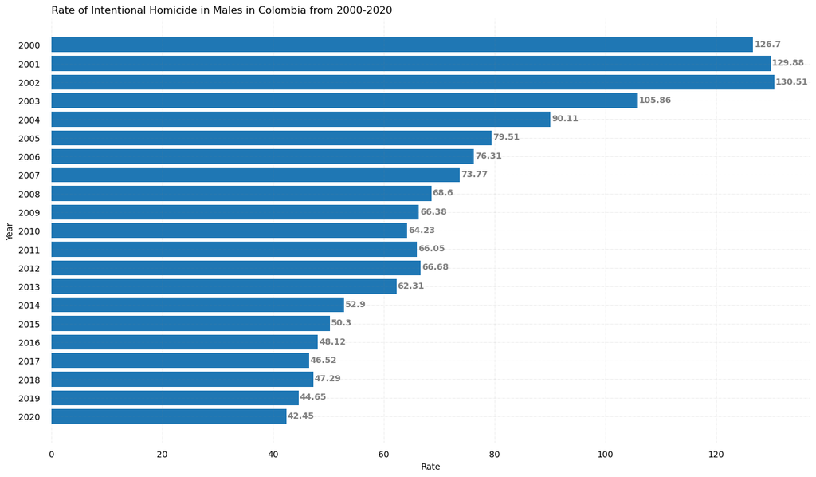

```python
import pandas as pd
from matplotlib import pyplot as plt

year = colombia_onlym['Year'].head(21)
rate = colombia_onlym['Rate'].head(21)

fig, ax = plt.subplots(figsize =(16, 9))

ax.barh(year, rate)

for s in ['top', 'bottom', 'left', 'right']:
    ax.spines[s].set_visible(False)

ax.xaxis.set_ticks_position('none')
ax.yaxis.set_ticks_position('none')

ax.xaxis.set_tick_params(pad = 5)
ax.yaxis.set_tick_params(pad = 10)

ax.grid(color ='grey',
        linestyle ='-.', linewidth = 0.5,
        alpha = 0.2)

ax.invert_yaxis()

for i in ax.patches:
    plt.text(i.get_width()+0.2, i.get_y()+0.5,
             str(round((i.get_width()), 2)),
             fontsize = 10, fontweight ='bold',
             color ='grey')

ax.set_title('Rate of Intentional Homicide in Males in Colombia from 2000-2020', loc ='left', )
plt.xlabel("Rate")
plt.ylabel("Year")

plt.show()
```

This chart shows the rate of intentional homicide in males in Colombia from 2000-2020. We see that the highest rate was 130.51 in the year 2002. This means that in the year 2002, there was approximately 130 males intentionally murdered per 100,000 people in the population of Colombia.

```python
colombia_onlyf = female_only[female_only['Country'] == 'Colombia']
colombia_onlyf
```

|  | Region | Subregion | Country | Gender | Year | Rate |
| --- | --- | --- | --- | --- | --- | --- |
| 2 | Americas | Latin America and the Caribbean | Colombia | Female | 2000 | 9.52 |
| 53 | Americas | Latin America and the Caribbean | Colombia | Female | 2001 | 10.79 |
| 104 | Americas | Latin America and the Caribbean | Colombia | Female | 2002 | 10.76 |
| 155 | Americas | Latin America and the Caribbean | Colombia | Female | 2003 | 9.46 |
| 206 | Americas | Latin America and the Caribbean | Colombia | Female | 2004 | 7.59 |
| 257 | Americas | Latin America and the Caribbean | Colombia | Female | 2005 | 6.86 |
| 308 | Americas | Latin America and the Caribbean | Colombia | Female | 2006 | 6.01 |
| 359 | Americas | Latin America and the Caribbean | Colombia | Female | 2007 | 6.21 |
| 410 | Americas | Latin America and the Caribbean | Colombia | Female | 2008 | 5.59 |
| 461 | Americas | Latin America and the Caribbean | Colombia | Female | 2009 | 5.52 |
| 512 | Americas | Latin America and the Caribbean | Colombia | Female | 2010 | 5.32 |
| 563 | Americas | Latin America and the Caribbean | Colombia | Female | 2011 | 5.79 |
| 614 | Americas | Latin America and the Caribbean | Colombia | Female | 2012 | 5.90 |
| 665 | Americas | Latin America and the Caribbean | Colombia | Female | 2013 | 5.16 |
| 716 | Americas | Latin America and the Caribbean | Colombia | Female | 2014 | 4.88 |
| 767 | Americas | Latin America and the Caribbean | Colombia | Female | 2015 | 4.41 |
| 818 | Americas | Latin America and the Caribbean | Colombia | Female | 2016 | 4.23 |
| 869 | Americas | Latin America and the Caribbean | Colombia | Female | 2017 | 4.32 |
| 920 | Americas | Latin America and the Caribbean | Colombia | Female | 2018 | 4.19 |
| 971 | Americas | Latin America and the Caribbean | Colombia | Female | 2019 | 4.08 |
| 1022 | Americas | Latin America and the Caribbean | Colombia | Female | 2020 | 3.53 |

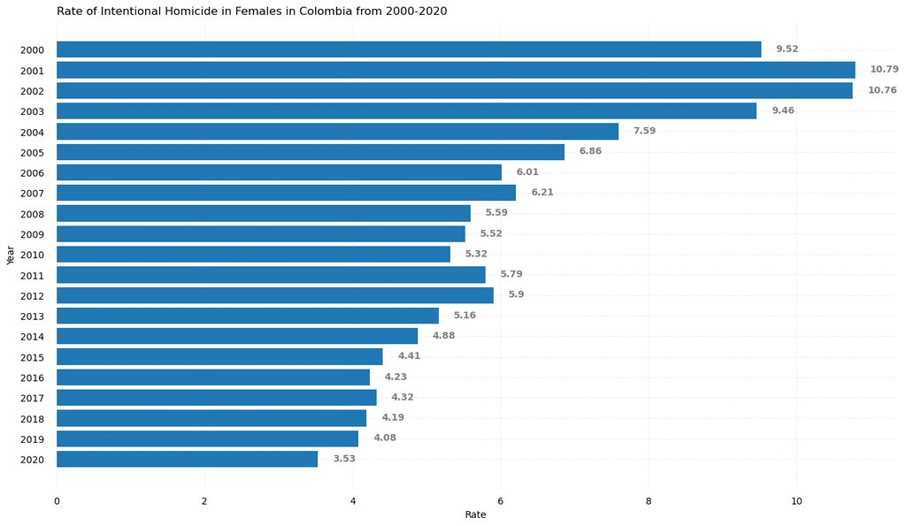

```python
year = colombia_onlyf['Year'].head(21)
rate = colombia_onlyf['Rate'].head(21)

fig, ax = plt.subplots(figsize =(16, 9))

ax.barh(year, rate)

for s in ['top', 'bottom', 'left', 'right']:
    ax.spines[s].set_visible(False)

ax.xaxis.set_ticks_position('none')
ax.yaxis.set_ticks_position('none')

ax.xaxis.set_tick_params(pad = 5)
ax.yaxis.set_tick_params(pad = 10)

ax.grid(color ='grey',
        linestyle ='-.', linewidth = 0.5,
        alpha = 0.2)

ax.invert_yaxis()

for i in ax.patches:
    plt.text(i.get_width()+0.2, i.get_y()+0.5,
             str(round((i.get_width()), 2)),
             fontsize = 10, fontweight ='bold',
             color ='grey')

ax.set_title('Rate of Intentional Homicide in Females in Colombia from 2000-2020', loc ='left', )
plt.xlabel("Rate")
plt.ylabel("Year")

plt.show()
```

This chart shows the rate of intentional homicide in females in Colombia from 2000-2020. We see that the highest rate was 10.79 in the year 2001. This means that in the year 2001, there was approximately 11 females intentionally murdered per 100,000 people in the population of Colombia. This is shockingly different when compared to the 130 males intentionally murdered in this same country in the same year.

```python
rf_onlyf = female_only[female_only['Country'] == 'Russian Federation']
rf_onlyf
```

|  | Region | Subregion | Country | Gender | Year | Rate |
| --- | --- | --- | --- | --- | --- | --- |
| 23 | Europe | Eastern Europe | Russian Federation | Female | 2000 | 13.27 |
| 74 | Europe | Eastern Europe | Russian Federation | Female | 2001 | 13.85 |
| 125 | Europe | Eastern Europe | Russian Federation | Female | 2002 | 13.84 |
| 176 | Europe | Eastern Europe | Russian Federation | Female | 2003 | 13.35 |
| 227 | Europe | Eastern Europe | Russian Federation | Female | 2004 | 12.53 |
| 278 | Europe | Eastern Europe | Russian Federation | Female | 2005 | 11.52 |
| 329 | Europe | Eastern Europe | Russian Federation | Female | 2006 | 9.40 |
| 380 | Europe | Eastern Europe | Russian Federation | Female | 2007 | 8.08 |
| 431 | Europe | Eastern Europe | Russian Federation | Female | 2008 | 5.85 |
| 482 | Europe | Eastern Europe | Russian Federation | Female | 2009 | 6.01 |
| 533 | Europe | Eastern Europe | Russian Federation | Female | 2010 | 5.66 |
| 584 | Europe | Eastern Europe | Russian Federation | Female | 2011 | 5.26 |
| 635 | Europe | Eastern Europe | Russian Federation | Female | 2012 | 5.49 |
| 686 | Europe | Eastern Europe | Russian Federation | Female | 2013 | 5.19 |
| 737 | Europe | Eastern Europe | Russian Federation | Female | 2014 | 5.40 |
| 788 | Europe | Eastern Europe | Russian Federation | Female | 2015 | 5.34 |
| 839 | Europe | Eastern Europe | Russian Federation | Female | 2016 | 5.33 |
| 890 | Europe | Eastern Europe | Russian Federation | Female | 2017 | 4.46 |
| 941 | Europe | Eastern Europe | Russian Federation | Female | 2018 | 4.06 |
| 992 | Europe | Eastern Europe | Russian Federation | Female | 2019 | 3.73 |
| 1043 | Europe | Eastern Europe | Russian Federation | Female | 2020 | 3.53 |

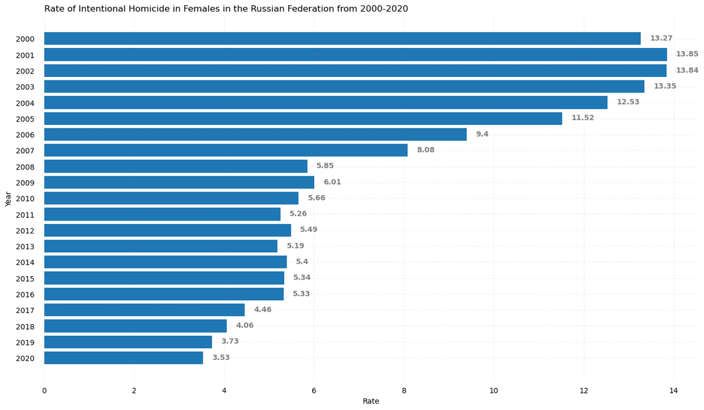

```python
year = rf_onlyf['Year'].head(21)
rate = rf_onlyf['Rate'].head(21)

fig, ax = plt.subplots(figsize =(16, 9))

ax.barh(year, rate)

for s in ['top', 'bottom', 'left', 'right']:
    ax.spines[s].set_visible(False)

ax.xaxis.set_ticks_position('none')
ax.yaxis.set_ticks_position('none')

ax.xaxis.set_tick_params(pad = 5)
ax.yaxis.set_tick_params(pad = 10)

ax.grid(color ='grey',
        linestyle ='-.', linewidth = 0.5,
        alpha = 0.2)

ax.invert_yaxis()

for i in ax.patches:
    plt.text(i.get_width()+0.2, i.get_y()+0.5,
             str(round((i.get_width()), 2)),
             fontsize = 10, fontweight ='bold',
             color ='grey')

ax.set_title('Rate of Intentional Homicide in Females in the Russian Federation from 2000-2020', loc ='left', )
plt.xlabel("Rate")
plt.ylabel("Year")

plt.show()
```

This chart shows the rate of intentional homicide in females in the Russian Federation from 2000-2020. We see that the highest rate was 13.85 in the year 2001. This means that in the year 2001, there was approximately 14 females intentionally murdered per 100,000 people in the population of the Russian Federation.

From looking at all of these generated graphs together, we can see that murder rate was the highest for both men and women between the years of 2000 and 2005. There seems to be a steady decrease in murder rate in both sexes after this time period.

We've now looked at the highest intentional homicide rate values throughout the years between males and females separately. Lets create a graphic to show the dramatic difference between the rates of intentional homicide between males and females in all countries.

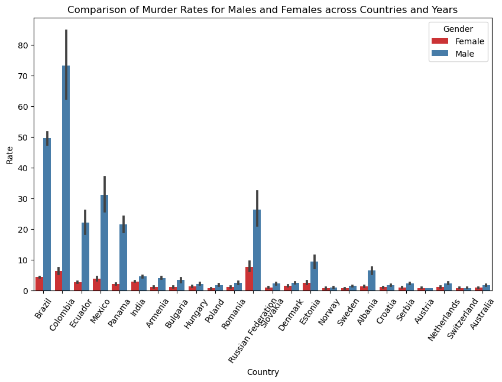

```python
plt.figure(figsize=(10, 6))
sns.barplot(x='Country', y='Rate', hue='Gender', data=data, palette='Set1')

# Adding labels and title
plt.xlabel('Country')
plt.xticks(rotation=55)
plt.ylabel('Rate')
plt.title('Comparison of Murder Rates for Males and Females across Countries and Years')
plt.show()
```

Finally, let's answer our question about whether intentional homicide rates of females differs between countries with strong women's rights and countries lacking in women's rights. For countries who have strong women's rights, we will use Norway, Switzerland, and the Netherlands. For countries lacking in women's rights, we will use India, Colombia, and Brazil. Although these three countries are not known for their lack of women's rights, it should be noted that they are the countries within our data which are the lowest on the list of the 2018 Women, Peace and Security Index. https://www.peacewomen.org/resource/and-worst-country-be-woman

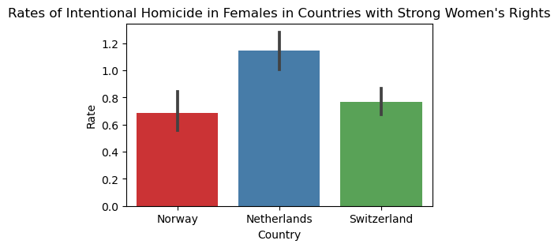

```python
top3countries = ['Norway', 'Switzerland', 'Netherlands']

datatop3 = female_only[female_only['Country'].isin(top3countries)]

plt.figure(figsize=(5, 3))
sns.barplot(x='Country', y='Rate', data=datatop3, palette='Set1')

plt.xlabel('Country')
plt.ylabel('Rate')
plt.title("Rates of Intentional Homicide in Females in Countries with Strong Women's Rights")

plt.show()
```

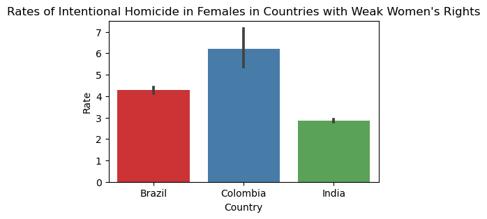

```python
bottom3countries = ['India', 'Colombia', 'Brazil']

databottom3 = female_only[female_only['Country'].isin(bottom3countries)]

plt.figure(figsize=(5, 3))
sns.barplot(x='Country', y='Rate', data=databottom3, palette='Set1')

plt.xlabel('Country')
plt.ylabel('Rate')
plt.title("Rates of Intentional Homicide in Females in Countries with Weak Women's Rights")

plt.show()
```

If we compare our top 3 women's rights countries to our bottom 3 women's rights countries, there is an obvious difference when looking at the scales of these two graphs. The rate of intentional homicide in females in the countries with poor women's rights is significantly higher, ranging up to 6.00. Conversely, in our data showing the top 3 countries with strong women's rights, we see that the scale only ranges up to about 1.10. This dramatic difference may be due to how women are treated and looked at by society in these countries.

# Summary